# STA321: Week #03 Assignment

Chloe Winters

9/15/2024

# 1 Part 1

## 1.1 Project Data Set

```r
  setwd("~/Desktop/Senior Year/STA 321/STA 321 -Fall 2024")
diabetes_predict <- read.csv("diabetes_prediction_dataset.csv")
  str(data)
```

```
## function (..., list = character(), package = NULL, lib.loc = NULL, verbose = getOption("verbose"),
##     envir = .GlobalEnv, overwrite = TRUE)
```

```r
diabetes_num <- dplyr::select(diabetes_predict, age, bmi, HbA1c_level, blood_glucose_level)
```

## 1.2 Data set requirements

The above data set meets

- the response variable **must** be continuous random variables.
  - There are continuous random variables that we can use in this data set as our response variable based on the question we are asking. In this case the response variable we are looking at is bmi.
- at least two categorical explanatory variables
  - There are at least two categorical explanatory variables in this data set. The first one is gender and the second one is smoking_history.
- at least one of the categorical variables has more than two categories.
  - The variable smoking_history has more than two categories.
- at least two numerical explanatory variables.
  - There are at least two numerical explanatory variables, one is age and another in bmi, however there are several more.
- at least 15 observations are required for estimating each regression coefficient. For example, if your final linear model has 11 variables (including dummy variables), you need $12 \times 15 = 180$ observations.
  - There are 100,000 observations in this data set and only 9 variables so we have surpassed the required amount of observations.

# 2 Part 2

## 2.1 Introduction

## 2.2 Materials

This assignment is going to look at diabetic prediction data. While there is no specific context regarding the collection of the data, the synopsis explains that the data set is a collection of demographic and medical data from patients. The data set has 100000 observations and 9 variables which are as followed,

gender: chr age: num hypertension: int heart_disease: int smoking_history: chr bmi: num HbA1c_level: num blood_glucose_level: int diabetes: int

A practical question to look into with this data set would be is there an observable relationship between any of these variables. An analytical question for this data set would be is it possible to use the relationships of those variables to predict one another without the use of the diabetes variable.

While the data set is smaller in terms of variables there are plenty of observations that is likely that we have enough information to answer the questions about the data set.

## 2.3 Methodolgy and Analysis

### 2.3.1 Scatterplots

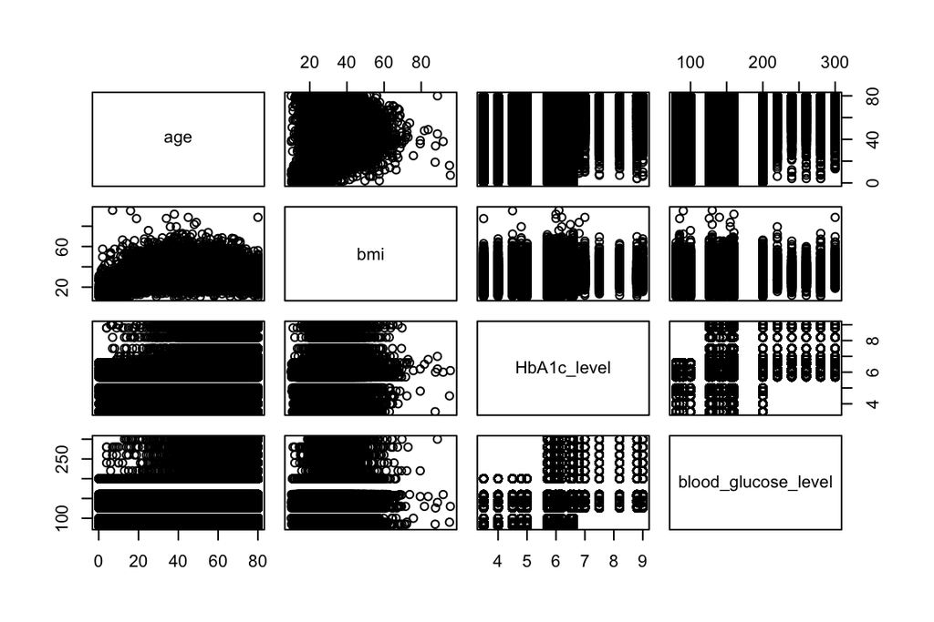

```r
pairs(diabetes_num)
```

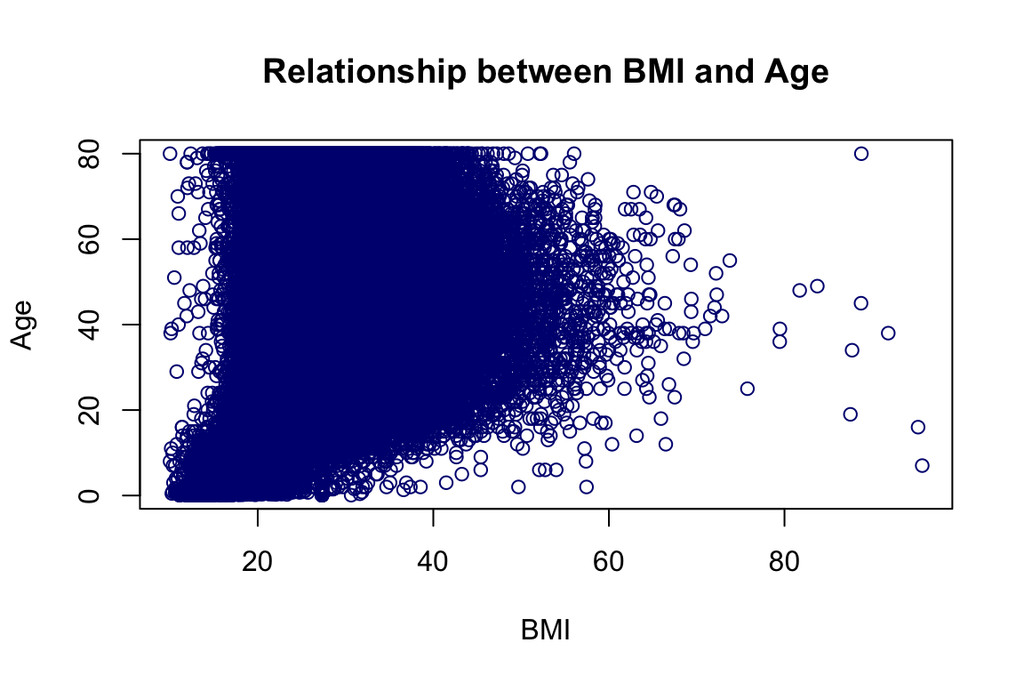

```r
BMI <- diabetes_predict$bmi
Age <- diabetes_predict$age
plot(BMI, Age, pch = 21, col ="navy",
     main = "Relationship between BMI and Age")
```

```r
model <- lm(formula = bmi ~ age, data = diabetes_predict)
summary(model)
```

```
##
## Call:
## lm(formula = bmi ~ age, data = diabetes_predict)
##
## Residuals:
##     Min      1Q  Median      3Q     Max
## -21.101  -3.791  -0.788   2.512  71.839
##
## Coefficients:
##              Estimate Std. Error t value Pr(>|t|)
## (Intercept) 2.316e+01  4.173e-02   554.9   <2e-16 ***
## age         9.945e-02  8.774e-04   113.3   <2e-16 ***
## ---
## Signif. codes:  0 '***' 0.001 '**' 0.01 '*' 0.05 '.' 0.1 ' ' 1
##
## Residual standard error: 6.248 on 99998 degrees of freedom
## Multiple R-squared:  0.1138, Adjusted R-squared:  0.1138
## F-statistic: 1.285e+04 on 1 and 99998 DF,  p-value: < 2.2e-16
```

Looking at the least square regression model for the variables we can see that BMI = 2.316e+01 + age*9.945e-02.

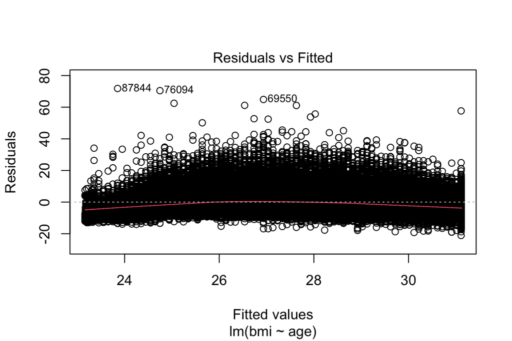

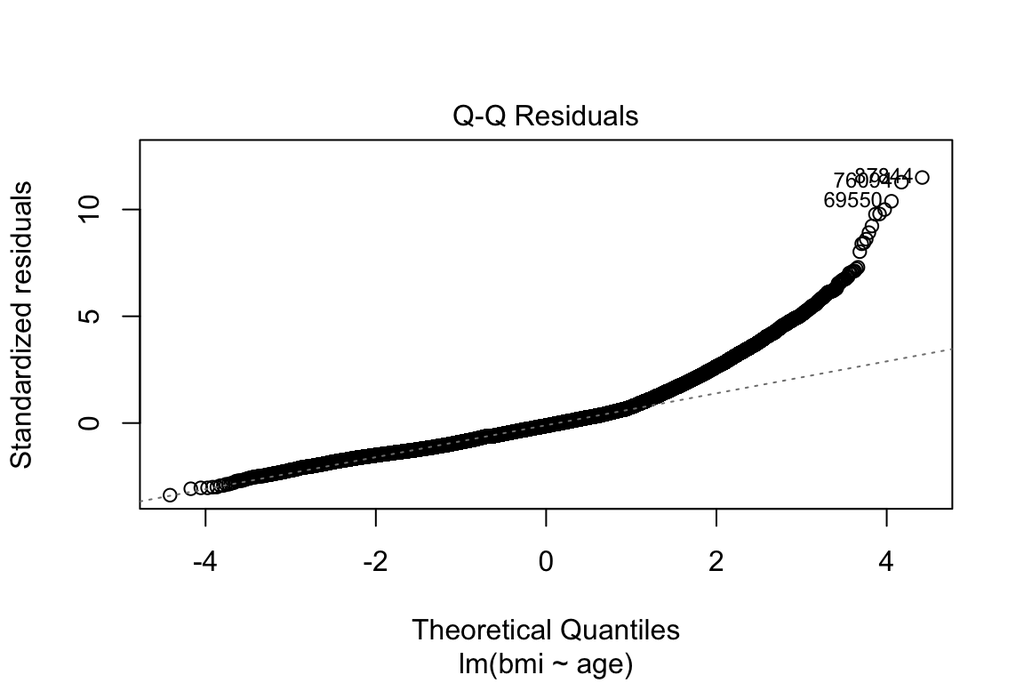

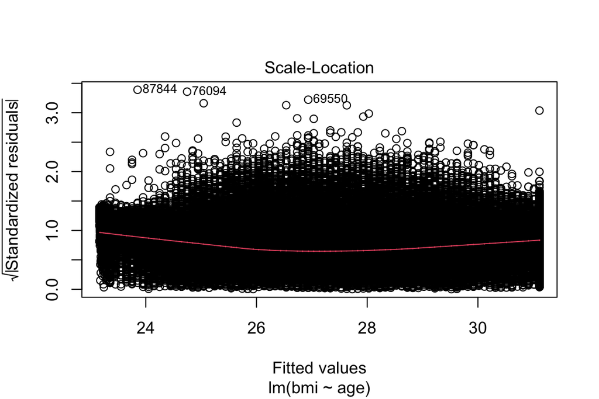

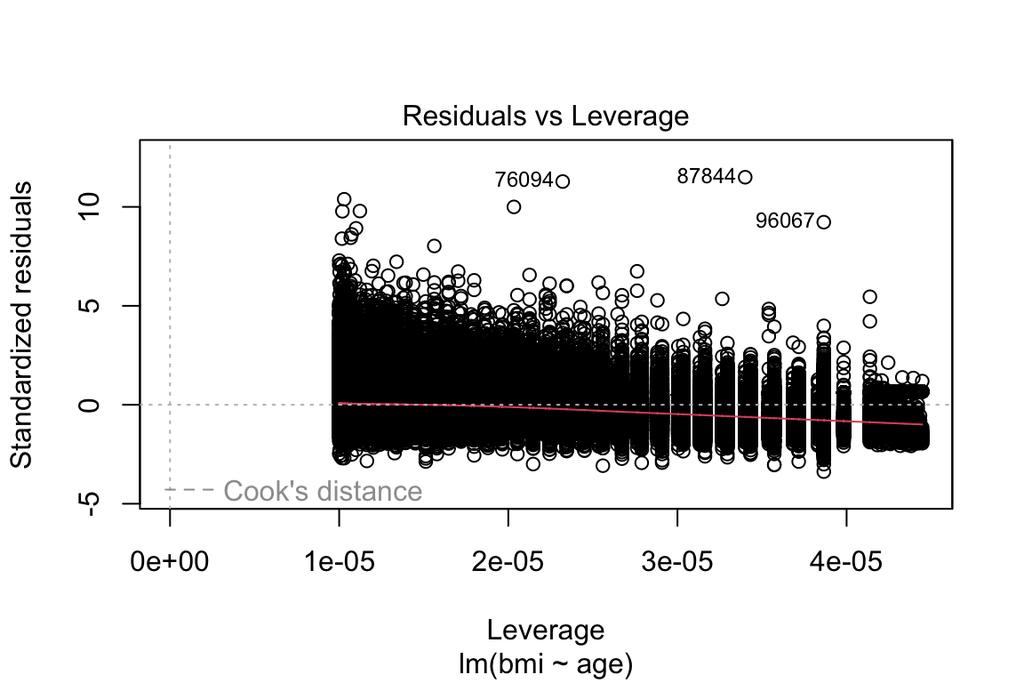

```r
plot(model)
```